# MODULE 2.4

## Objectives:

### How to alter the spatial extent of raster- and vector-based data.

#### STUDENT WORKSHOP: USING R TO MODEL, MANIPULATE, AND MANAGE SPATIAL DATA

#### IALE 2015 World Congress, Portland, OR USA 7 July 2015

> Karl Jarvis, Northern Arizona University

> Whalen Dillon, North Carolina State University

> Jill Deines, Michigan State University

> Francesco Tonini, North Carolina State University

> Thomas Edwards, U.S. Geological Survey and Utah State University

#### MODULE 2.4 CODE BY:

> Thomas C. Edwards, U.S. Geological Survey and Department of Wildland Resources

> Utah State University, Logan UT 84322-5230 USA t.edwards@usu.edu

> (Tested on R versions 3.1.X, 3.2.X)

### Let's begin.

Start by loading some important libraries, …

```r
## some libraries ...
   library(rgdal)     # fxns: readOGR, writeOGR
   library(raster)    # fxns: crop, mask
```

… and set some paths for data access.

```r
## some initializations ...
## these paths will be specific to your CPU; alter as needed
   #path.root <- "~/IALE2015_gisRcourse"
   path.dat="E:/IALE2015_gisRcourse/data"
   #path.root <- "~/words/classes/IALE2015_gisRcourse"
   #path.dat <- paste(path.root, "/data", sep = "")
   setwd(path.dat)
```

### Subsetting From a Polygon

Start by importing some polygons using **readOGR()**. The first of these is a polygon of a study region, the Colorado Plateau of western North America (**cp.region**). The second (**states**) is all the states/provinces in North America. By now you should know it is always a good strategy to examine the imported shapefiles to ensure they are similar in spatial characteristics.

```r
## import shapefile to be cropped
##   CP study area; the "mask" for cropping
   cp.region <- readOGR(dsn = ".", layer = "COP_boundpoly_aea")
##   north American states/provinces to be cropped
   states <- readOGR(dsn = ".", layer = "na_states_aea")
   cp.region;  states  # examine each
```

```
class       : SpatialPolygonsDataFrame
features    : 1
extent      : -1540636, -959647.5, 1521625, 2076339  (xmin, xmax, ymin, ymax)
coord. ref. : +proj=aea +lat_1=29.5 +lat_2=45.5 +lat_0=23 +lon_0=-96 +x_0=0 +y_0=0 +datum=NAD83 +units=m +no_defs +ellps=GRS80 +towgs84=0,0,0
variables   : 1
names       : Id
min values  :  0
max values  :  0

class       : SpatialPolygonsDataFrame
features    : 95
extent      : -6293578, 3189093, -893447.8, 6198911  (xmin, xmax, ymin, ymax)
coord. ref. : +proj=aea +lat_1=29.5 +lat_2=45.5 +lat_0=23 +lon_0=-96 +x_0=0 +y_0=0 +datum=NAD83 +units=m +no_defs +ellps=GRS80 +towgs84=0,0,0
variables   : 2
names       : CODE,           NAME
min values  :   AK, Aguascalientes
max values  :   WY,      Zacatecas
```

Here, we wish to extract four state polygons (UT, CO, NM, AZ) from the **states** shapepoly. If you are uncertain about the codes assigned to elements in any shapepoly, you can always examine them prior to implementing the subset by going directly to the slot **states@data** or by calling the attribute name as in **states$CODE**.

```r
## examine aspects of the shapepoly data structure
   head(states@data)  # examine shapepoly data
```

```
  CODE                      NAME
0 CA10                    Quebec
1 CA06     Northwest Territories
2 CA07               Nova Scotia
3 CA11              Saskatchewan
4 CA01                   Alberta
5 CA05 Newfoundland and Labrador
```

```r
## examine the possible state codes
   states$CODE  # state codes
```

```
 [1] CA10 CA06 CA07 CA11 CA01 CA05 CA02 CA04 CA09 CA12 CA03 CA08 MX02 MX03 MX18 MX14 MX01 MX11 MX22 MX13 MX16 MX15 MX09 MX08 MX17 MX31 MX04 MX21 MX23 MX29 MX12
[32] MX20 MX27 MX05 MX26 MX06 MX07 MX25 MX10 MX32 MX24 MX19 MX28 MX30 WA   MT   ME   ND   SD   WY   WI   ID   VT   MN   OR   NH   IA   MA   NE   NY   PA   CT
[63] RI   NJ   IN   NV   UT   CA   OH   IL   DC   DE   WV   MD   CO   KY   KS   VA   MO   AZ   OK   NC   TN   TX   NM   AL   MS   GA   SC   AR   LA   FL   MI
[94] HI   AK
95 Levels: AK AL AR AZ CA CA01 CA02 CA03 CA04 CA05 CA06 CA07 CA08 CA09 CA10 CA11 CA12 CO CT DC DE FL GA HI IA ID IL IN KS KY LA MA MD ME MI MN MO MS MT ... WY
```

Subsetting a shapepoly in R is no different than subsetting data meeting a condition in any R data.frame; simply set the condition for subsetting using any R operator, such as **==**. The subsetting code below also includes a **!is.na()** condition.

A quirk in rgdal-based extractions is that presence of a NA in the variable being examined for subsetting (here, **CODE**) can lead to an error. Thus it is safest to include the **!is.na()** condition as well, which reads as “*… and is not a missing value*”.

```r
## subset states meeting condition
##   NOTE: rgdal squirrelly; must exclude NA or crashes if NA present
   cp.states <- states[states$CODE == "UT" & !is.na(states$CODE) |
                       states$CODE == "CO" & !is.na(states$CODE) |
                       states$CODE == "NM" & !is.na(states$CODE) |
                       states$CODE == "AZ" & !is.na(states$CODE), ]
   cp.states@data  # examine subsetted states
```

The polyshape after the subset (**cp.states**) now includes only the four states of interest. If you plan on using the subset states in other analyses or plots, consider saving the shapepoly using the **writeOGR()** call.

```
   CODE       NAME
66   UT       Utah
74   CO   Colorado
79   AZ    Arizona
84   NM New Mexico
```

So did the subsetting work? If it did, you would have three shapepolys, all of the North American states/provinces, the four states subset from North America, and a polygon of the Colorado Plateau. A so-called “*Giggle Test*” plot is the fastest way to see if your polygons meet your expectations. If the plot doesn''t meet expectations, you haven''t passed the *Giggle Test* and need to figure out what went wrong.

Plots are simple. Plot the first base plot, and use the option **add = T** to plot the others on top of the base and each other.

```r
## giggle plots
   plot(states, main = "N American States: \nColorado Plateau & Associated US States")  # all states
   plot(cp.states, add = T, col = "blue")  # the subsetted states
   plot(cp.region, add = T, col = "red")  # the study region
```

The plot seems reasonable; the Giggle Test is passed.

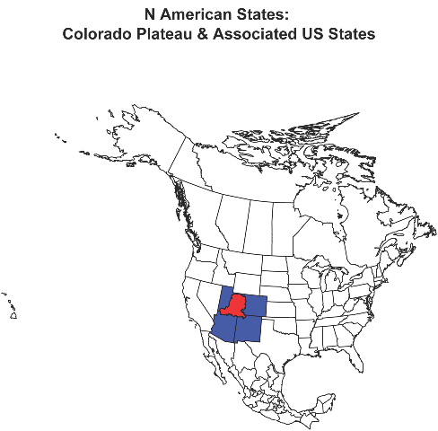

### Crop a Polygon with Another Polygon

There are two common methods for cropping one polygon by another. These are the **crop()** (package **raster**) and **gIntersection** calls (package **rgeos**). (NOTE: When cropping with polygons, raster actually calls the dependency package **rgeos** to perform the crop.) Again, consider saving the newly cropped polygon with **writeOGR()** if you plan on using it frequently.

```r
## crop states to the CP region
   cp.statesCROP1 <- crop(cp.states, cp.region)
## output shapefile if desired; examine in ArcGIS if desired
   #writeOGR(cp.statesCROP1, dsn = "./outdata", layer = "cp.statesCROP1",
   #  morphToESRI = T, driver = "ESRI Shapefile")
## giggle plots
   par(mfrow=c(1,2))
   ## plot #1
   plot(cp.states, main = "4 States with CP Overlay")  # giggle plot
   plot(cp.statesCROP1, add = T, border = "red")
   ## plot #2
   plot(cp.statesCROP1, border = "red", main = "4 States Cropped by CP")
```

The first plot shows all four states with cropped boundaries overlaid in red, while the second plot portrays the state boundaries as cropped by the Colorado Plateau polygon.

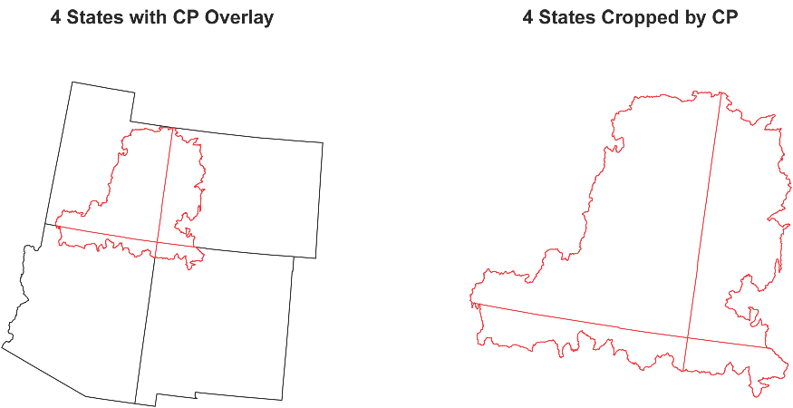

```r
## output shapefile if desired; examine in ArcGIS if desired
   #writeOGR(cp.statesCROP1, dsn = "./outdata", layer = "cp.statesCROP1",
   #  morphToESRI = T, driver = "ESRI Shapefile")
```

The **gIntersection()** call operates like **crop()**.

```r
## alternative using gIntersection; pkg rgeos
   #cp.statesCROP2 <- gIntersection(cp.states, cp.region, byid = T)  # NOT RUN
```

### Crop a Raster with a Polygon

To crop a raster with a polygon requires several steps, which could be an easy R function to write if done repeatedly. Let''s start with an imported raster of average temperature (**tave**), and once again use the Colorado Plateau polygon (**cp.region**) as our study region of interest. We will crop **tave** to the area of **cp.region**.

Check the spatial characteristics of each prior to the crop. Here, we have two different projection and must transform one so that both are the same.

```r
##   import a raster to crop
   tave <- raster("tave_yr_av.img")
   tave;  cp.region  # examine input raster & polygon
```

```
class       : RasterLayer
dimensions  : 4200, 3600, 15120000  (nrow, ncol, ncell)
resolution  : 0.008333333, 0.008333333  (x, y)
extent      : -125, -95, 20, 55  (xmin, xmax, ymin, ymax)
coord. ref. : +proj=longlat +datum=WGS84 +no_defs +ellps=WGS84 +towgs84=0,0,0
data source : C:\Users\tce\Documents\words\classes\IALE2015_gisRcourse\data\tave_yr_av.img
names       : tave_yr_av

class       : SpatialPolygonsDataFrame
features    : 1
extent      : -1540636, -959647.5, 1521625, 2076339  (xmin, xmax, ymin, ymax)
coord. ref. : +proj=aea +lat_1=29.5 +lat_2=45.5 +lat_0=23 +lon_0=-96 +x_0=0 +y_0=0 +datum=NAD83 +units=m +no_defs +ellps=GRS80 +towgs84=0,0,0
variables   : 1
names       : Id
min values  :  0
max values  :  0
```

We''ll use **spTransform()** to convert the projection of **cp.region** (AEA) to that of **tave** (WGS84).

```r
## NOTE diff projections; must convert 1 to match other (see Module 2.2)
   cp.regionWGS <- spTransform(cp.region, CRS = CRS(projection(tave)))
   projection(cp.regionWGS);  projection(tave)  # both w/same projection now
```

Both projections are now the same. The **crop()** can now begn.

```
[1] "+proj=longlat +datum=WGS84 +no_defs +ellps=WGS84 +towgs84=0,0,0"
[1] "+proj=longlat +datum=WGS84 +no_defs +ellps=WGS84 +towgs84=0,0,0"
```

The goal of the crop is to extract only the values for the raster layer that are inside the Colorado Plateau, as shown in red on the plot.

```r
## giggle plots; goal is crop of tave to match red in plot
   plot(tave, main = "Regional tave with Colorado Plateau Study region")
   plot(cp.regionWGS, add = T, col = "red")
```

Plot showing the desired study region (**cp.ragion**) within the broader extent of raster data (**tave**).

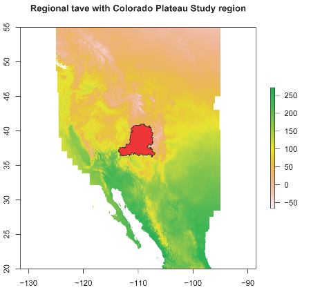

Let''s get started with the crop. We first use the **mask()** call (package **raster**) to mask out all **tave** values outside of the Colorado Plateau study region.

```r
## step #1;  fxn mask() w/CP polygon as mask applied to tave
   taveCROP.1 <- mask(tave, cp.regionWGS)
## giggle plots; LOL here .....
   plot(taveCROP.1)  # NOTE extent is extent of tave
   plot(extent(taveCROP.1), add = T)
```

When we look at the plot output, this process flunks the Giggle Test. The **cp.region** extraction of the **tave** looks good; however, the black vertical lines indicate the extent of the plot, which is the same extent as that of the original **tave** raster. While the **mask** seems ot have masked out **tave** values outside the **cp.region**, it did not reduce the extent to that of the **cp.region**.

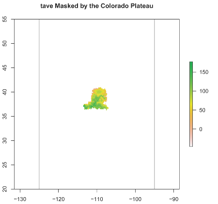

To obtain the correct extent, simply **crop()** the masked region with **cp.region**.

```r
## step #2; fxn crop() to subset masked tave to extent of CP region
   taveCROP.2 <- crop(taveCROP.1, cp.regionWGS)
## giggle plots ...
   plot(taveCROP.2)
   plot(cp.regionWGS, add = T)
## outfile cropped raster if desired
   #writeRaster(taveCROP.2, filename = "outdata/cp.taveCROP2.img", format = "HFA")
```

The plot looks great, and the underlying raster is the one you want to save using the **writeRaster()** code above.

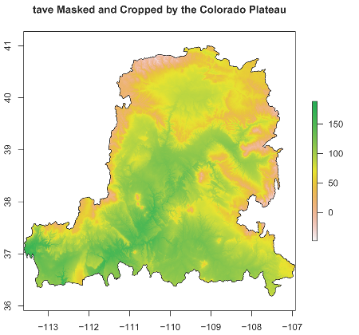

### Crop a Raster with a Raster

Start by loading an additional raster, **cp.rast**, which is a raster of the Colorado Plateau study region. Compare it and the raster **tave** to ensure both have the same spatial characteristics.

```r
## assume raster of region to serve as crop; here cp.rast (see Module 2.2)
   load("outdata/cp.rast.RData")  # raster of CP region
   cp.rast; tave  # examine; tave will be cropped by cp.region
```

```
class       : RasterLayer
dimensions  : 638, 861, 549318  (nrow, ncol, ncell)
resolution  : 0.008333333, 0.008333333  (x, y)
extent      : -113.85, -106.675, 35.93333, 41.25  (xmin, xmax, ymin, ymax)
coord. ref. : +proj=longlat +datum=WGS84 +no_defs +ellps=WGS84 +towgs84=0,0,0
data source : in memory
names       : layer
values      : 1, 1  (min, max)

class       : RasterLayer
dimensions  : 4200, 3600, 15120000  (nrow, ncol, ncell)
resolution  : 0.008333333, 0.008333333  (x, y)
extent      : -125, -95, 20, 55  (xmin, xmax, ymin, ymax)
coord. ref. : +proj=longlat +datum=WGS84 +no_defs +ellps=WGS84 +towgs84=0,0,0
data source : C:\Users\tce\Documents\words\classes\IALE2015_gisRcourse\data\tave_yr_av.img
names       : tave_yr_av
```

The plots below portrays the goal of the crop - you just want the area in the red, which is the Colorado PLateau study region.

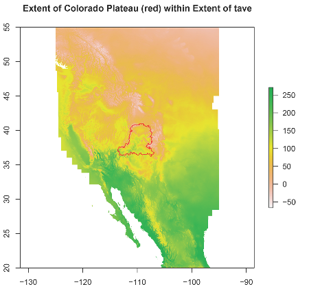

```r
## some giggle plots; crop goal is area bounded in red
   plot(tave, main = "Extent of Colorado Plateau (red) within Extent of tave")
   plot(cp.regionWGS, add = T, border = "red")
```

```r
## crop tave raster w/cp.rast raster
   taveCROP.3 <- crop(tave, cp.rast)
## outfile cropped raster if desired
   #writeRaster(taveCROP.3, filename = "outdata/cp.taveCROP3.img", format = "HFA")
## giggle plots; NOTE that crop is cp.rast extent, not just CP region
   plot(taveCROP.3, main = "Extent of tave Cropped by Colorado Plateau")
   plot(cp.regionWGS, add = T, border = "black")
```

The extent, which is the rectangle surrounding the Colorado Plateau polygon, is now correct after applying the **crop()**. However, the crop also includes **tave** values outside the Colorado Plateau boundary *per se*.

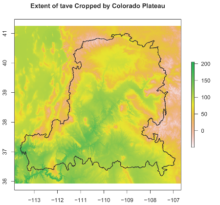

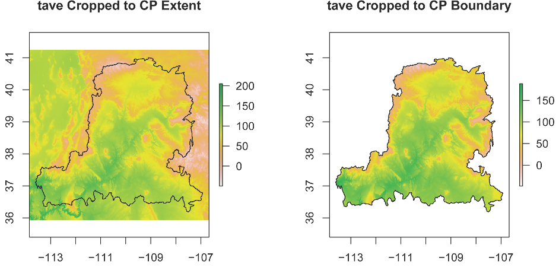

```r
## mulitply rasters if desire cp.rast only; otherwise default is rectangle of extent
   taveCROP.4 <- cp.rast * taveCROP.3  # NOTE; cp.rast has value => NA outside of CP per se
## giggle plots
   par(mfrow = c(1, 2))
   plot(taveCROP.3, main = "Extent of tave Cropped to \nColorado Plateau Extent")
   plot(cp.regionWGS, add = T, border = "black")
   plot(taveCROP.4, main = "Extent of tave Cropped to \nColorado Plateau Boundary")
   plot(cp.regionWGS, add = T, border = "black")
## outfile cropped raster if desired
   #writeRaster(taveCROP.4, filename = "outdata/cp.taveCROP4.img", format = "HFA")
```

### Crop a Polygon with a Raster

Before cropping a polygon with a raster ensure that both have the same projection and are of correct class. Both **soil.poly** and **cp.rast** are in WGS84, and are of classes **SpatialPolygonsDataFrame** and **RasterLayer**, respectively.

```r
## import a shapepoly
   soil.poly <- readOGR(dsn = ".", layer = "soils")  # be patient here ...
## examine polygon & raster; both have same projection?  if not see Module 2.2/2.3
   soil.poly;  cp.rast  # examine polygon & raster
```

```
class       : SpatialPolygonsDataFrame
features    : 6721
extent      : -115.853, -104.678, 33.93571, 43.25238  (xmin, xmax, ymin, ymax)
coord. ref. : +proj=longlat +datum=WGS84 +no_defs +ellps=WGS84 +towgs84=0,0,0
variables   : 44
names       :  mukey,  taxorder, taxsuborde,  taxgrtgrou,                        taxsubgrp, subord, grtgrp, c_order, c_sbord, c_ggrp, phmin, phave, phmax, frag3to10, sieveno4, ...
min values  : 657964,  Alfisols,    Aquents, Aquicambids, Abruptic Argiduridic Durixerolls,    Aqu,    Aqu,     100,     100,    100,     0,     0,     0,         0,        0, ...
max values  : 848685, Vertisols,    Xerolls, Xerorthents,             Xeric Torripsamments,    Xer,    Xer,     110,     127,    141,   840,   900,  1100,        48,      100, ...

class       : RasterLayer
dimensions  : 638, 861, 549318  (nrow, ncol, ncell)
resolution  : 0.008333333, 0.008333333  (x, y)
extent      : -113.85, -106.675, 35.93333, 41.25  (xmin, xmax, ymin, ymax)
coord. ref. : +proj=longlat +datum=WGS84 +no_defs +ellps=WGS84 +towgs84=0,0,0
data source : in memory
names       : layer
values      : 1, 1  (min, max)
```

Apply the **crop()** to the polygon. As was observed above, the crop results in the rectangular extent of the underlying raster used as the crop.

You cannot, however, multiply the two objects together as done above and have as a result soil polygons cropped precisely to the boundary of the Colorado Plateau. If that is your desire, use the **gIntersection()** (see above, **Crop a Polygon with Another Polygon**), which will crop the soil polygon to the boundary polygon.

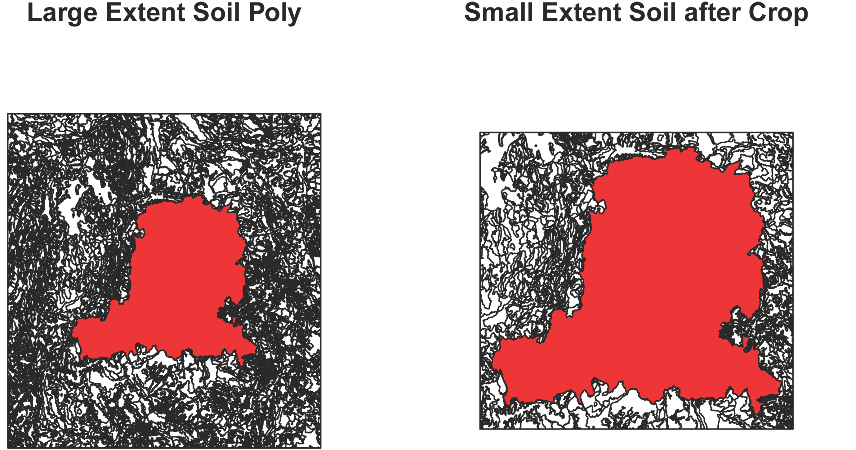

```r
## crop polygon w/extent of raster
   soilCROP.1=crop(soil.poly,extent(cp.rast))
## giggle plots
   par(mfrow = c(1, 2))
   plot(soil, main = "Large Extent Soil Poly")
   plot(cp.regionWGS, add = T, col = "red")
   plot(soilCROP.1, main = "Small Extent Soil after Crop")
   plot(cp.regionWGS, add = T, col = "red")
```

### Summary

The procedures outlined in this Module allow you alter extents of polygons and raster both for analytical and plotting purposes. Key aspects to remember include ensuring that the spatial characteristics are of same projection co-mingling polygons and rasters, and that for raster to raster operation that resolutions are the same as well.

### END MODULE 2.4